# Dataset creation

An image with 60 handwritten characters was taken an converted into 60 different images. The following bash script was used to preprocess the 60 images:

```python
#!/bin/sh
  for i in $(cut -d, -f1 labels.csv)
  do
  root=`echo $i| sed -e 's/\(.*\)\..*/\1/'`

#convert png to vx
  vfmt  -g -png if=$root.PNG of=$root.vx

#convert to grayscale, invert and threshold at 128
  vpix th=128 -neg if=$root.vx of=$root.th.vx

#Resize image to 20x20
  vimag s=20,20,1 if=$root.th.vx of=$root.th.size.vx

#Center the 20x20 image in a 28x28 image using center of mass
  vcenter if=$root.th.size.vx of=$root.c.vx

#Convert vx to png
  vxport -png if=$root.c.vx of=$root.png

#Remove temporary files
  rm $root.vx
  rm $root.th.vx
  rm $root.th.size.vx
  rm $root.c.vx
  rm $root.PNG

  done


 Code for vcenter.c:


/*******************************************************************/
/* vcenter        reposition image using center of mass            */
/*******************************************************************/
#include "VisXV4.h"	/* VisionX structure include file    */
#include "Vutil.h"	/* VisionX utility header files      */
VXparam_t par[] =       /* command line structure            */
{ 			/* prefix, value,   description      */
{    "if=",    0,   " input file  "},
{    "of=",    0,   " output file "},
{     0,       0,   0}  /* list termination */
};
#define	IVAL par[0].val
#define	OVAL par[1].val
int main(argc, argv)
int argc;
char *argv[];
{
Vfstruct (im);        	   /* i/o image structure        			  */
Vfstruct (tm);             /* temp image structure       			  */
int y,x;               	   /* index counters             			  */
int s;         		       /* image size          			          */
int cx=0,xsum=0,sum=0;	   /* variables used for calculating center of mass 	  */
int cy=0,ysum=0;           /* variables used for calculating center of mass 	  */
float bbx[6];   	   /* bounding box for image 			  */
  VXparse(&argc, &argv, par);       /* parse the command line       */

/* create VX image for result */
  s = 28;  /* set size of result image */
  bbx[0] = bbx[2] = bbx[4] = bbx[5] = 0.0;
  bbx[1] = bbx[3] = s;
  Vfnewim(&tm, VX_PBYTE, bbx, 1);

  while( Vfread(&im, IVAL) ) {     /* read image file              */
	if( im.type != VX_PBYTE ) {    /* check image format           */
       		fprintf(stderr, "no byte image data in input file\n");
       		exit(-1);
     	}

	/* check that the input image is small enough */
	if ( (im.xhi - im.xlo ) > (tm.xhi - tm.xlo) ||
             (im.yhi - im.ylo ) > (tm.yhi - tm.ylo) ) {
             fprintf(stderr, "Input image too large\n");
             exit(-1);
     	}
	/* compute center of mass */
	for (y = im.ylo ; y <= im.yhi ; y++) {
		for (x = im.xlo; x <= im.xhi; x++)  {
           		xsum = xsum + x*im.u[y][x];
			ysum = ysum + y*im.u[y][x];
			sum = sum + im.u[y][x];
         	}
     	}
	cx=xsum/sum;
	cy=ysum/sum;
	/* this loop assumes tm.xlo and tm.ylo are 0 but not im.xlo and im.ylo */
	for (y = tm.ylo ; y <= tm.yhi ; y++) {  /* compute the function */
		for (x = tm.xlo; x <= tm.xhi; x++)  {
			if((im.ylo<=(cy-14+y))&&(im.yhi>=(cy-14+y))&&(im.xlo<=(cx-14+x))&&(im.xhi>=(cx-14+x)))
           			tm.u[y][x] = im.u[cy-14+y][cx-14+x];
			else
				tm.u[y][x] =0;
         	}
     	}
    	Vfwrite(&tm, OVAL);             /* write image file                */
  }
  exit(0);
}
```

# Logistic Regression

```python
import time
import io
import matplotlib.pyplot as plt
import numpy as np
from scipy.io.arff import loadarff

from sklearn.datasets import get_data_home
from sklearn.externals.joblib import Memory
from sklearn.linear_model import LogisticRegression
from sklearn.model_selection import train_test_split
from sklearn.preprocessing import StandardScaler
from sklearn.utils import check_random_state
from urllib.request import urlopen
```

```python
#2.  read the NMIST dataset
memory = Memory(get_data_home())
@memory.cache()
def fetch_mnist():
    content = urlopen(
        'https://www.openml.org/data/download/52667/mnist_784.arff').read()
    data, meta = loadarff(io.StringIO(content.decode('utf8')))
    data = data.view([('pixels', '<f8', 784), ('class', '|S1')])
    return data['pixels'], data['class']
X, y = fetch_mnist()
```

```python
# rescale the data, use the traditional train/test split

X = X / 255.

X_train, X_test = X[:60000], X[60000:]
y_train, y_test = y[:60000], y[60000:]
```

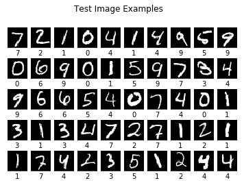

```python
### Bounus 1: show the first ten images
### ALways a good idea to validate that the data appears as you expect
###
### for sci-kit learn the images are represented as vectors of 784 elements
### currently scaled from 0 to 1

for i in range(50):
    l1_plot = plt.subplot(5, 10, i + 1)
    l1_plot.imshow(255 * X_test[i].reshape(28, 28), interpolation='nearest',
                   cmap=plt.cm.gray)
    l1_plot.set_xticks(())
    l1_plot.set_yticks(())
    #l1_plot.set_xlabel('Class %s' % y_test[i].decode())
    l1_plot.set_xlabel('%i' % int(y_test[i]))
plt.suptitle('Test Image Examples')
plt.show()
```

```python
## for this demonstration each pixel scale is normalized
## by the mean and standared deviation of the training set
## note the mean and stadard deviation are set by the
## taining set only.
## why is this done?
scaler = StandardScaler()
X_train = scaler.fit_transform(X_train)
X_test = scaler.transform(X_test)
```

```python
#train and test classifier
# Turn up tolerance for faster convergence
clf = LogisticRegression(C=50. / 1000,
                         multi_class='multinomial',
                         penalty='l1', solver='saga', tol=0.1)
# Train the classifier
clf.fit(X_train, y_train)


#Evaluate the classifier

sparsity = np.mean(clf.coef_ == 0) * 100
score = clf.score(X_test, y_test)
# print('Best C % .4f' % clf.C_)
print("Sparsity with L1 penalty: %.2f%%" % sparsity)
print("Test score with L1 penalty: %.4f" % score)
```

```
Sparsity with L1 penalty: 17.95%
Test score with L1 penalty: 0.9019
```

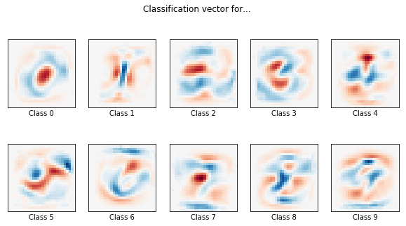

```python
# Bonus 2: Visualization of the weights
# This is only possible for simple classifiers

coef = clf.coef_.copy()
plt.figure(figsize=(10, 5))
scale = np.abs(coef).max()
for i in range(10):
    l1_plot = plt.subplot(2, 5, i + 1)
    l1_plot.imshow(coef[i].reshape(28, 28), interpolation='nearest',
                   cmap=plt.cm.RdBu, vmin=-scale, vmax=scale)
    l1_plot.set_xticks(())
    l1_plot.set_yticks(())
    l1_plot.set_xlabel('Class %i' % i)
plt.suptitle('Classification vector for...')
plt.show()
```

```
Confusion matrix, without normalization
```

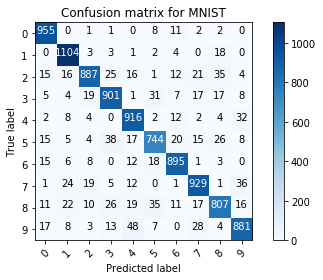

```python
### Bonus 3: comfusion matrix visualization tool
## A more elegant preserntation for a confusion matrix

from sklearn.metrics import confusion_matrix
y_predict = clf.predict(X_test)
cfm = confusion_matrix(y_test, y_predict)

import itertools
def plot_confusion_matrix(cm, classes,
                          normalize=False,
                          title='Confusion matrix',
                          cmap=plt.cm.Blues):
    """
    This function prints and plots the confusion matrix.
    Normalization can be applied by setting `normalize=True`.
    """
    if normalize:
        cm = cm.astype('float') / cm.sum(axis=1)[:, np.newaxis]
        print("Normalized confusion matrix")
    else:
        print('Confusion matrix, without normalization')

    #print(cm)

    plt.imshow(cm, interpolation='nearest', cmap=cmap)
    plt.title(title)
    plt.colorbar()
    tick_marks = np.arange(len(classes))
    plt.xticks(tick_marks, classes, rotation=45)
    plt.yticks(tick_marks, classes)

    fmt = '.2f' if normalize else 'd'
    thresh = cm.max() / 2.
    for i, j in itertools.product(range(cm.shape[0]), range(cm.shape[1])):
        plt.text(j, i, format(cm[i, j], fmt),
                 horizontalalignment="center",
                 color="white" if cm[i, j] > thresh else "black")

    plt.ylabel('True label')
    plt.xlabel('Predicted label')
    plt.tight_layout()

plot_confusion_matrix(cfm, classes=range(10),
                      title='Confusion matrix for MNIST')
```

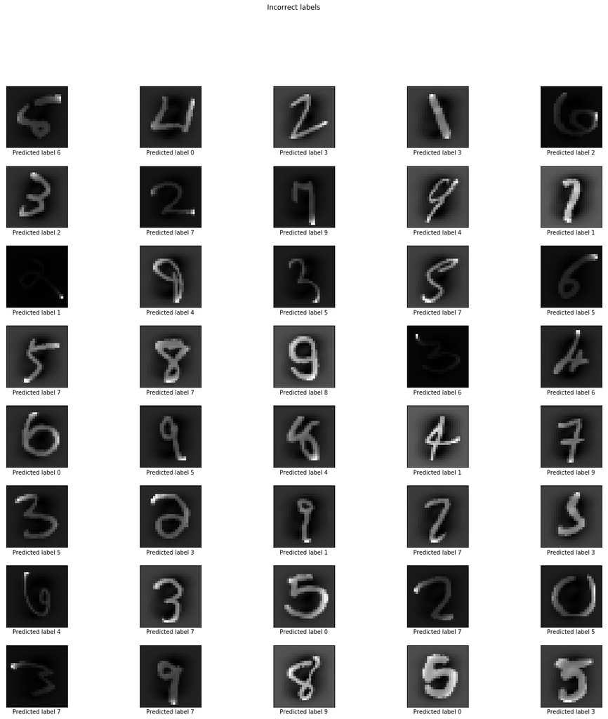

```python
error=[]
for j in range(1000):
    if y_predict[j]!=y_test[j]:
        error.append(j)
    j=j+1
plt.figure(figsize=(20, 20))
for i in range(40):
    l1_plot = plt.subplot(8, 5, i + 1)
    l1_plot.imshow(255 * X_test[error[i]].reshape(28, 28), interpolation='nearest', cmap=plt.cm.gray)
    l1_plot.set_xticks(())
    l1_plot.set_yticks(())
    plt.subplots_adjust(hspace=0.3, wspace=0.3)
    l1_plot.set_xlabel('Predicted label %i' % int(y_predict[error[i]]))
plt.suptitle('Incorrect labels')
plt.show()
```

The logistic regression classifier works well on the MNIST dataset as indicated by the test score using L1 penalty. The classifier obtained a score of 0.902. Figure above shows 40 of the images that were labeled incorrectly. As evident from the images above, most of these errors are due to the test image being dark and the character unclear. Looking at the characters themselves it can be argued that the classifier performance is at par with that of an average human.

```python
""" Custom datatset loader
    based on https://github.com/utkuozbulak/pytorch-custom-dataset-examples
"""
import pandas as pd
import imageio

class SimpleDataset():
    def __init__(self, data_path, csv_name, transform = None ):
        """
        Args:
            data_path (string): path to the folder where images and csv files are located
            csv_name (string): name of the csv lablel file
            transform: pytorch transforms for transforms and tensor conversion
        """
        # Set path
        self.data_path = data_path
        # Read the csv file
        self.data_info = pd.read_csv(data_path + csv_name, header=None)
        # First column contains the image paths
        self.image_arr = np.asarray(self.data_info.iloc[:, 0])
        # Second column is the labels
        self.label_arr = np.asarray(self.data_info.iloc[:, 1])
        # Calculate len
        self.data_len = len(self.data_info.index)

    def __getitem__(self, index):
        # Get image name from the pandas df
        single_image_name = self.image_arr[index]
        # Open image
        img_as_img = imageio.imread(self.data_path + single_image_name)

        # Get label(class) of the image based on the cropped pandas column
        single_image_label = self.label_arr[index]

        return (img_as_img, single_image_label)

    def __len__(self):
        return self.data_len
```

```python
mydata = SimpleDataset( "./idata/", "labels.csv")

#splitting into images and labels
X = []
y = []
for i in range(len(mydata)):
    X.append(mydata[i][0])
    y.append(mydata[i][1])

#converting into numpy arrays to enable easy reshaping and other array operations

X = np.asarray(X)
print("Shape of the input image", X.shape)
y= np.asarray(y)
y=y.astype('|S1')
```

```
Shape of the input image (60, 28, 28)
```

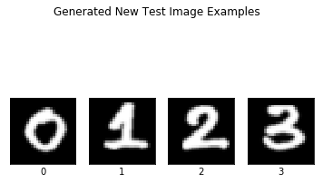

```python
import warnings
warnings.filterwarnings('ignore')
#l1_plot = plt.subplot(1, 4, i + 1)
for i in range(4):
    l1_plot = plt.subplot(1, 4, i + 1)
    l1_plot.imshow(X[i], interpolation='nearest',
                   cmap=plt.cm.gray)
    l1_plot.set_xticks(())
    l1_plot.set_yticks(())
    l1_plot.set_xlabel('%i' % int(y[i]))
plt.suptitle('Generated New Test Image Examples')
plt.show()
```

```python
#reshaping the array into flattened 784 array as an input for prediciton by the logistic regression classifier
X_tmp = X.reshape(X.shape[0], 784)
X_tmp = X_tmp / 255.
#data standardiation with the training set statistics is required for this clasifier
X_tmp = scaler.fit_transform(X_tmp)

y_pred = clf.predict(X_tmp)

score = clf.score(X_tmp, y)

print("Test score with L1 penalty: %.4f" % score)
print("y_predicted_values", y_pred)
print("y_labels", y)
```

```
Test score with L1 penalty: 0.6167
y_predicted_values [b'0' b'2' b'2' b'6' b'9' b'5' b'4' b'7' b'8' b'3' b'0' b'1' b'2' b'3'
 b'9' b'5' b'6' b'7' b'8' b'0' b'0' b'1' b'2' b'3' b'4' b'5' b'6' b'9'
 b'6' b'9' b'0' b'1' b'2' b'3' b'4' b'5' b'6' b'2' b'8' b'9' b'0' b'1'
 b'2' b'3' b'9' b'5' b'6' b'7' b'6' b'3' b'4' b'1' b'7' b'9' b'9' b'4'
 b'1' b'1' b'4' b'7']
y_labels [b'0' b'1' b'2' b'3' b'4' b'5' b'6' b'7' b'8' b'9' b'0' b'1' b'2' b'3'
 b'4' b'5' b'6' b'7' b'8' b'9' b'0' b'1' b'2' b'3' b'4' b'5' b'6' b'7'
 b'8' b'9' b'0' b'1' b'2' b'3' b'4' b'5' b'6' b'7' b'8' b'9' b'0' b'1'
 b'2' b'3' b'4' b'5' b'6' b'7' b'8' b'9' b'a' b'b' b'c' b'd' b'e' b'#'
 b'*' b'+' b'=' b')']
```

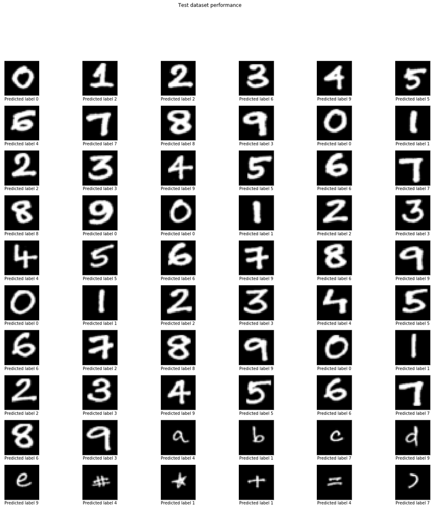

```python
error=[]
plt.figure(figsize=(20, 20))
for i in range(60):
    l1_plot = plt.subplot(10, 6, i + 1)
    l1_plot.imshow(X[i], interpolation='nearest', cmap=plt.cm.gray)
    l1_plot.set_xticks(())
    l1_plot.set_yticks(())
    plt.subplots_adjust(hspace=0.3, wspace=0.3)
    l1_plot.set_xlabel('Predicted label %i' % int(y_pred[i]))
plt.suptitle('Test dataset performance')
plt.show()
```

The classifier performed reasonably well on the smaller dataset with a score of 0.6167. The highest score that can be expected is 0.8333. The classifier was tested with two sets of small datasets. The first set which had smaller characters within the 28X28 image performed very poorly with a score of 0.24. Logistic regression classifier seems to be very sensitive to scaling.